# Iris dataset — Exploratory analysis

Somnath Chaudhuri

November 10, 2025

# Introduction

This short training document shows step-by-step exploratory data analysis (EDA) for the classic **Iris** dataset. The goal is to demonstrate a compact, reproducible workflow with concise interpretation notes so that learners can quickly understand key patterns before moving to modelling.

We keep the structure intentionally compact (few chunks) so it is easy to read and use in a workshop or self-study.

# Quick data check

We start with dimension, structure and simple summaries to understand variables and missingness.

```r
# dimensions and first rows
dim(iris)
```

```
## [1] 150   5
```

```r
names(iris)
```

```
## [1] "Sepal.Length" "Sepal.Width"  "Petal.Length" "Petal.Width"  "Species"
```

```r
head(iris)
```

|  | Sepal.Length | Sepal.Width | Petal.Length | Petal.Width | Species |
| --- | --- | --- | --- | --- | --- |
| 1 | 5.1 | 3.5 | 1.4 | 0.2 | setosa |
| 2 | 4.9 | 3.0 | 1.4 | 0.2 | setosa |
| 3 | 4.7 | 3.2 | 1.3 | 0.2 | setosa |
| 4 | 4.6 | 3.1 | 1.5 | 0.2 | setosa |
| 5 | 5.0 | 3.6 | 1.4 | 0.2 | setosa |
| 6 | 5.4 | 3.9 | 1.7 | 0.4 | setosa |

```r
# factor levels and class balance
levels(iris$Species)
```

```
## [1] "setosa"     "versicolor" "virginica"
```

```r
table(iris$Species)
```

```
##
##     setosa versicolor  virginica
##         50         50         50
```

```r
# summary statistics
summary(iris)
```

```
##   Sepal.Length    Sepal.Width     Petal.Length    Petal.Width
##  Min.   :4.300   Min.   :2.000   Min.   :1.000   Min.   :0.100
##  1st Qu.:5.100   1st Qu.:2.800   1st Qu.:1.600   1st Qu.:0.300
##  Median :5.800   Median :3.000   Median :4.350   Median :1.300
##  Mean   :5.843   Mean   :3.057   Mean   :3.758   Mean   :1.199
##  3rd Qu.:6.400   3rd Qu.:3.300   3rd Qu.:5.100   3rd Qu.:1.800
##  Max.   :7.900   Max.   :4.400   Max.   :6.900   Max.   :2.500
##        Species
##  setosa    :50
##  versicolor:50
##  virginica :50
##
##
##
```

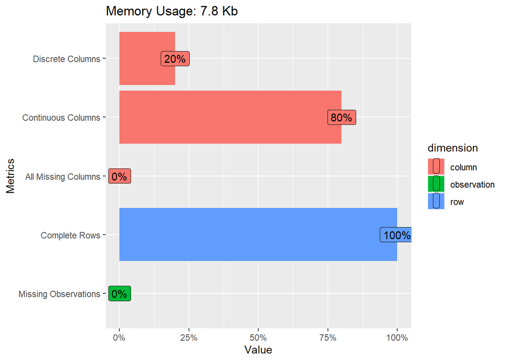

```r
# simple missingness & intro plot
plot_intro(iris)
```

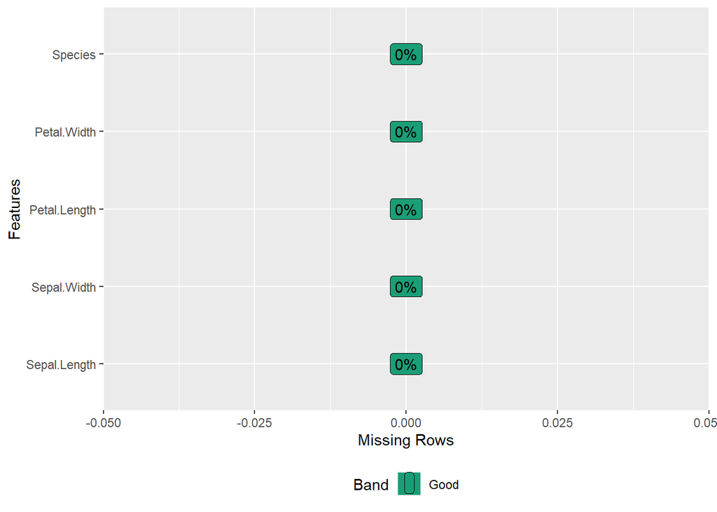

```r
plot_missing(iris)
```

**What we are doing:** Confirm dataset size (150 observations, 5 variables), variable types (4 numeric predictors and a factor Species), class balance (equal). The `plot_missing` will confirm no missing values.

# Univariate distributions

Visualize distributions of numeric variables to inspect skew, spread and potential outliers.

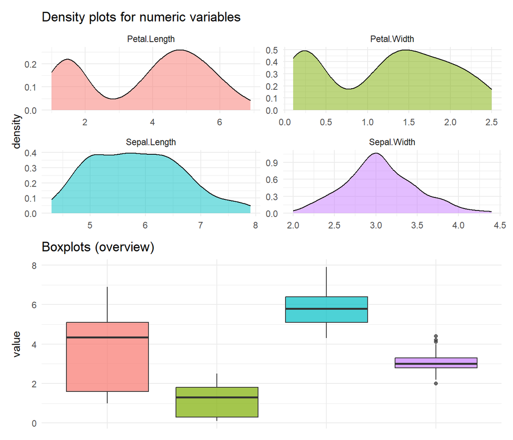

```r
# density plots for each numeric variable
iris_long <- iris %>% pivot_longer(cols = 1:4, names_to = "variable", values_to = "value")

p_density <- ggplot(iris_long, aes(x = value, fill = variable)) +
  geom_density(alpha = 0.5) +
  facet_wrap(~variable, scales = 'free') +
  labs(title = 'Density plots for numeric variables', x = NULL) +
  theme_minimal() +
  theme(legend.position = 'none')

# boxplots (compact)
p_box <- ggplot(iris_long, aes(x = variable, y = value, fill = variable)) +
  geom_boxplot(alpha = 0.7) +
  labs(title = 'Boxplots (overview)', x = NULL) +
  theme_minimal() +
  theme(axis.text.x = element_blank(), legend.position = 'none')

p_density / p_box
```

**Inference:** Petal measurements are more spread and show clear separation between species (later we will show species overlay). Sepal measurements overlap more.

# Bivariate relationships (by species)

We want to visualise relationships that are useful for classification: petal dimensions are known to separate species well.

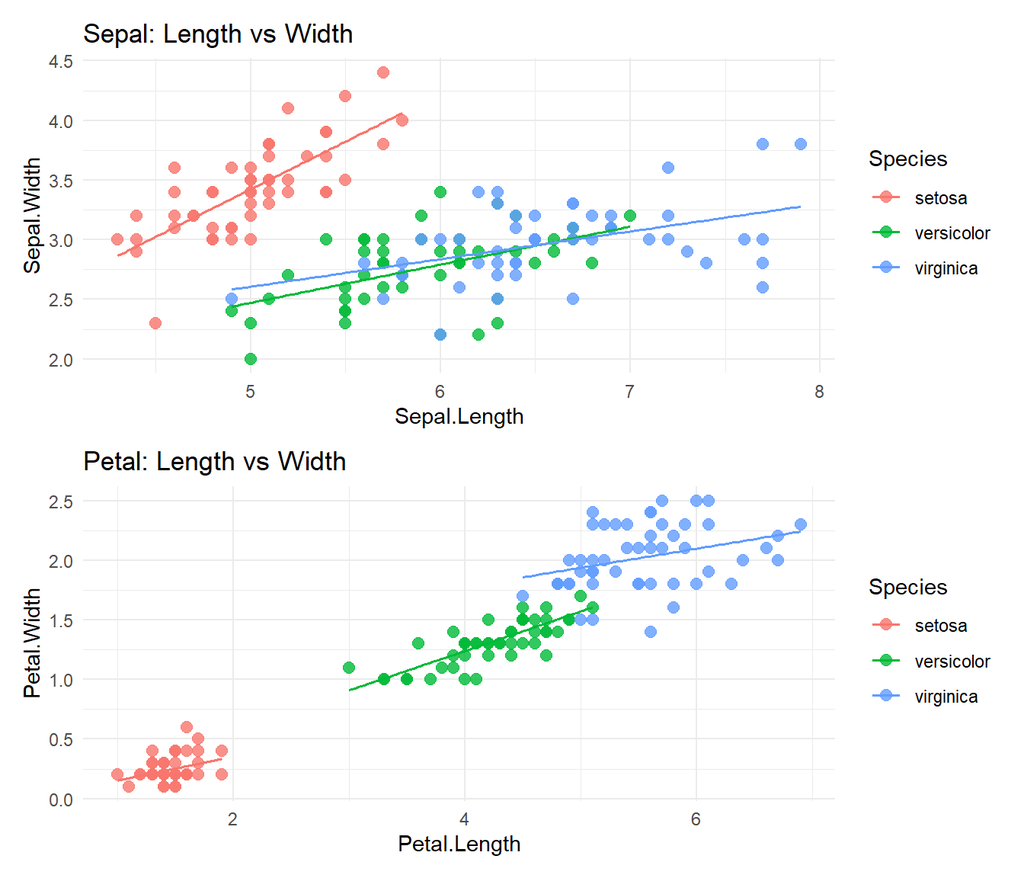

```r
# Sepal scatter
p1 <- ggplot(iris, aes(x = Sepal.Length, y = Sepal.Width, color = Species)) +
  geom_point(size = 2.5, alpha = 0.8) +
  geom_smooth(method = 'lm', se = FALSE, size = 0.6) +
  labs(title = 'Sepal: Length vs Width') +
  theme_minimal()

# Petal scatter
p2 <- ggplot(iris, aes(x = Petal.Length, y = Petal.Width, color = Species)) +
  geom_point(size = 2.5, alpha = 0.8) +
  geom_smooth(method = 'lm', se = FALSE, size = 0.6) +
  labs(title = 'Petal: Length vs Width') +
  theme_minimal()

# combine
p1 / p2
```

**Inference:** Petal Length vs Petal Width gives a very clear separation of species (especially *setosa* vs others). Sepal measurements overlap more and are less separable.

# Boxplots & violins by species (concise)

Compare distributions across species for each variable.

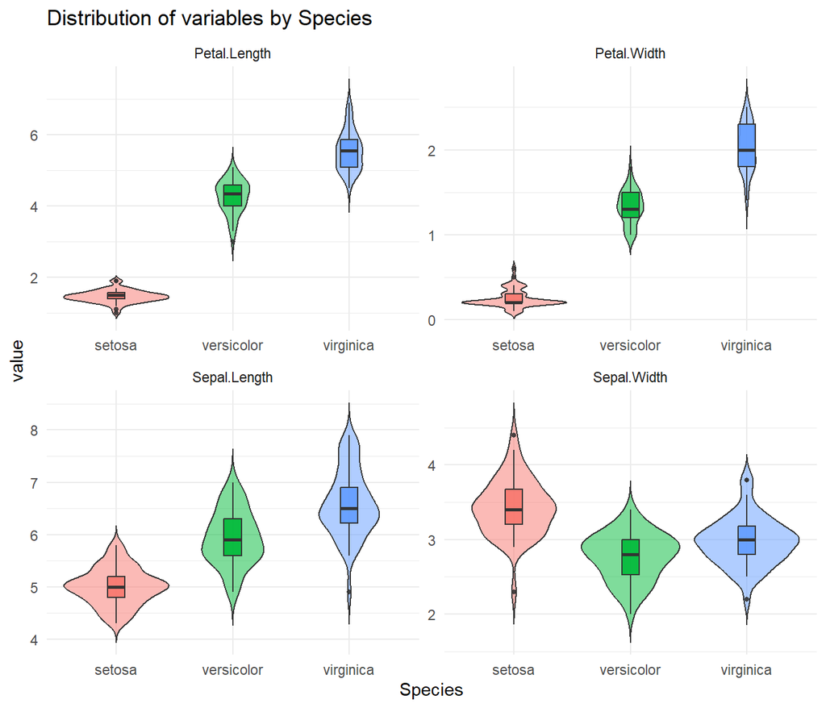

```r
# violin + boxplot overlay for clarity
p_v <- ggplot(iris_long, aes(x = Species, y = value, fill = Species)) +
  geom_violin(alpha = 0.5, trim = FALSE) +
  geom_boxplot(width = 0.15, outlier.size = 1, alpha = 0.9) +
  facet_wrap(~variable, scales = 'free', ncol = 2) +
  labs(title = 'Distribution of variables by Species') +
  theme_minimal() +
  theme(legend.position = 'none')

p_v
```

**Inference:** Petal variables show a stepwise increase across species: *setosa* has the smallest values, *versicolor* intermediate, *virginica* largest. Sepal differences are smaller.

# Correlation matrix (numeric variables)

A numeric correlation matrix is useful to quantify relationships.

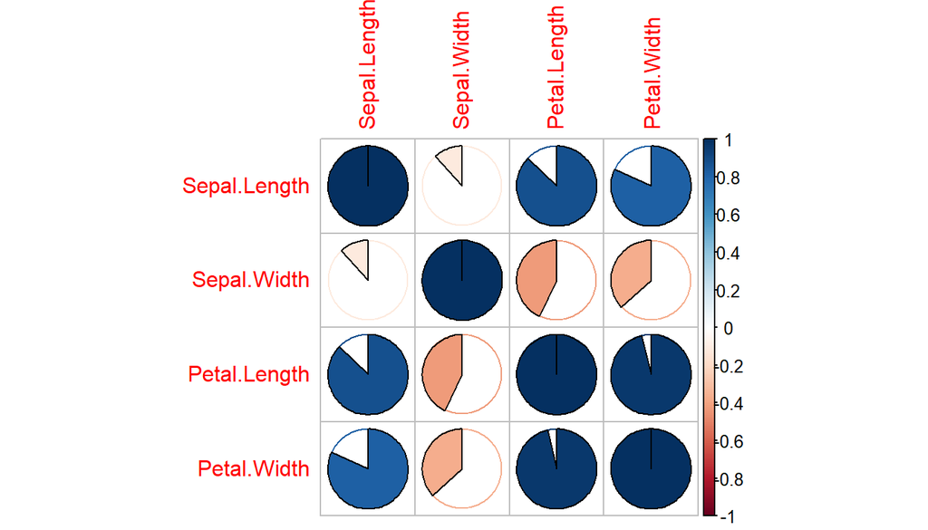

```r
num <- iris %>% select_if(is.numeric)
M <- cor(num)

corrplot(M, method = "pie")
```

```r
# Print matrix for reference
round(M, 2)
```

```
##              Sepal.Length Sepal.Width Petal.Length Petal.Width
## Sepal.Length         1.00       -0.12         0.87        0.82
## Sepal.Width         -0.12        1.00        -0.43       -0.37
## Petal.Length         0.87       -0.43         1.00        0.96
## Petal.Width          0.82       -0.37         0.96        1.00
```

# Pairwise scatter matrix with correlations

A compact pairwise plot helps detect multicollinearity and strong bivariate patterns.

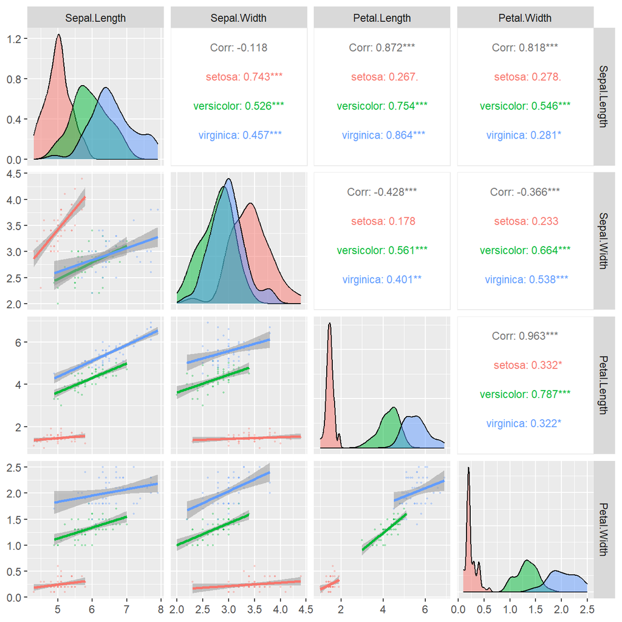

```r
# Use GGally ggpairs with species colouring; limit to numeric columns
ggpairs(iris, columns = 1:4,
        mapping = ggplot2::aes(color = Species, alpha = 0.6),
        upper = list(continuous = wrap('cor', size = 3)),
        lower = list(continuous = wrap('smooth', alpha = 0.3, size = 0.4)),
        diag = list(continuous = wrap('densityDiag', alpha = 0.5)))
```

**What to look for:** Strong correlation between Petal.Length and Petal.Width (high collinearity). This matters for some models and suggests that petal measurements are highly informative.

# Quick feature engineering & readiness checks

Before modelling, we often standardize and optionally create derived features. Here we show a small example (petal ratio) and a scaled dataset summary.

```r
# create a simple derived feature: petal aspect (length / width)
iris2 <- iris %>% mutate(Petal.Ratio = Petal.Length / Petal.Width)

summary(iris2$Petal.Ratio)
```

```
##    Min. 1st Qu.  Median    Mean 3rd Qu.    Max.
##   2.125   2.802   3.300   4.310   4.667  15.000
```

```r
# scaled predictors ready for models
iris_scaled <- as.data.frame(scale(iris %>% select(-Species)))
iris_scaled$Species <- iris$Species

head(iris_scaled)
```

|  | Sepal.Length | Sepal.Width | Petal.Length | Petal.Width | Species |
| --- | --- | --- | --- | --- | --- |
| 1 | -0.8976739 | 1.01560199 | -1.335752 | -1.311052 | setosa |
| 2 | -1.1392005 | -0.13153881 | -1.335752 | -1.311052 | setosa |
| 3 | -1.3807271 | 0.32731751 | -1.392399 | -1.311052 | setosa |
| 4 | -1.5014904 | 0.09788935 | -1.279104 | -1.311052 | setosa |
| 5 | -1.0184372 | 1.24503015 | -1.335752 | -1.311052 | setosa |
| 6 | -0.5353840 | 1.93331463 | -1.165809 | -1.048667 | setosa |

**Inference:** Petal ratio is another discriminative feature; scaling centers predictors for algorithms that require it (SVM, k-NN, PCA, etc.).

# Short checklist before modelling

1. Data balance: classes are balanced (50 each).
2. Missing values: none.
3. Strong predictors: petal length/width — consider variable selection or retain all and regularize.
4. Feature scaling: recommended for distance-based or regularized models.